```r
# Definición de variables para el problema
# Para este problema, podemos variar los tiempos de las diferentes fases
# del vuelo

# Vector con posibles valores para los tiempos (en segundos)
# Tiempo de aumento de altura (25-35 seg)
tiempos_aumento <- sample(seq(25, 35, by = 5), 1)
# Tiempo de vuelo horizontal (antes pirueta + giro) (18-32 seg)
tiempos_horizontal <- sample(seq(18, 32, by = 2), 1)
# Tiempo de aterrizaje (20-30 seg)
tiempos_aterrizaje <- sample(seq(20, 30, by = 5), 1)

# Alturas máximas posibles (en metros)
altura_maxima <- sample(seq(100, 200, by = 20), 1)

# Definir variables para mostrar en el texto del problema
tiempo_total <- tiempos_aumento + tiempos_horizontal + tiempos_aterrizaje
```

# Question

En una entrevista para una cadena de televisión, un piloto de un avión de acrobacias comenta en detalle cómo fue su presentación:

“Durante los primeros 25 segundos aumenté la altura de manera constante hasta alcanzar la altura máxima. Después mantuve la misma altura durante 28 segundos mientras realizaba diversas maniobras de exhibición. Para finalizar, aterricé reduciendo la altura de manera constante durante 25 segundos”.

¿Cuál de las siguientes gráficas representa de forma CORRECTA la información dada por el piloto?

## Answerlist

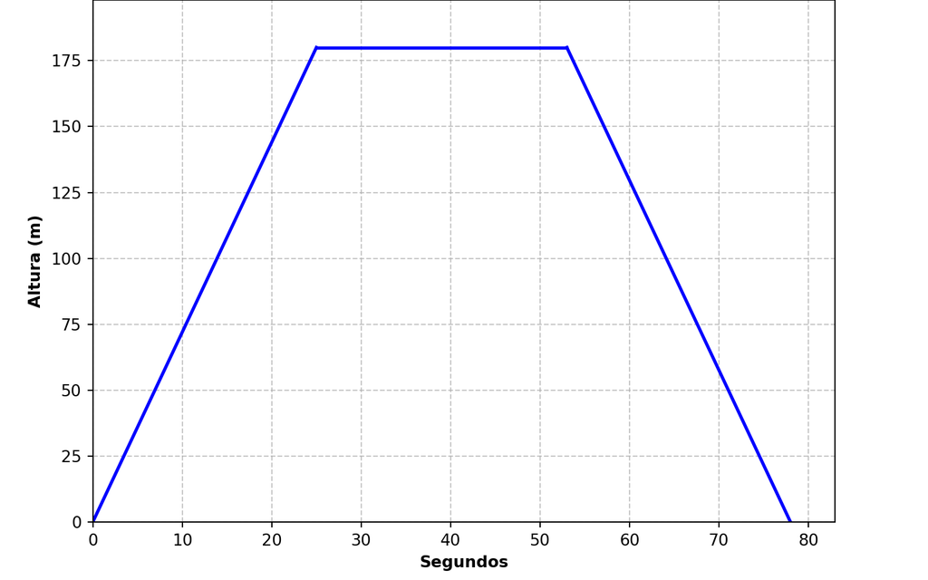

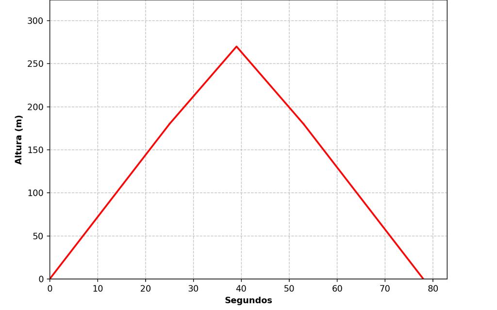

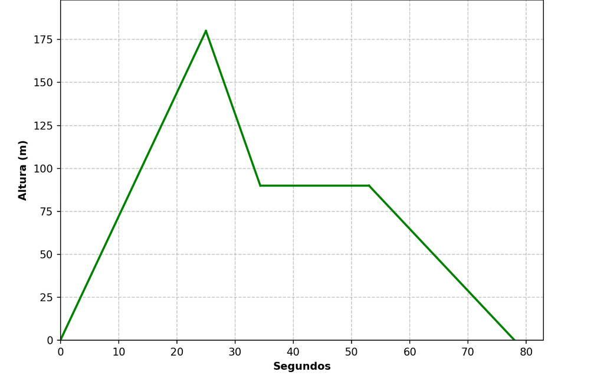

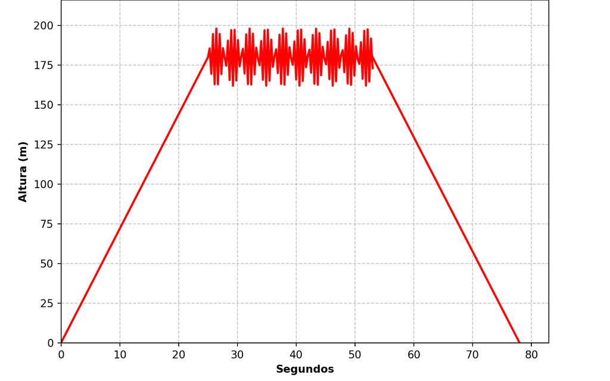

# Solution

La gráfica correcta es la que representa adecuadamente las tres fases del vuelo acrobático descritas por el piloto:

1. Durante los primeros 25 segundos: aumento constante de altura (línea ascendente).
2. Mantenimiento de la misma altura durante 28 segundos mientras realizaba maniobras de exhibición (línea horizontal).
3. Aterrizaje con reducción constante de altura durante 25 segundos (línea descendente final).

Esta gráfica es la primera (A), que tiene color azul y muestra exactamente las tres fases descritas, sin elementos adicionales.

Las demás opciones contienen elementos incorrectos: - La gráfica B muestra un pico de altura durante las maniobras, pero el piloto mencionó que mantuvo la misma altura. - La gráfica C muestra un descenso durante las maniobras y luego mantiene una altura constante menor, lo cual contradice la descripción del piloto. - La gráfica D muestra oscilaciones en la altura durante las maniobras, cuando el piloto especificó que mantuvo la misma altura.

# Meta-information

exname: vuelo_acrobatico(single-choice) extype: schoice exsolution: 1000 exshuffle: TRUE exsection: Interpretación de gráficas